# Análise Ambiental

Bioengenharia de Água e Solo  
aplicada à Recuperação Ambiental

Luiz Diego Vidal Santos

## Visão Geral da Aula

### Tópicos

- 1 Princípios da bioengenharia
- 2 Técnicas vegetativas
- 3 Técnicas estruturais leves
- 4 Estabilização de margens e taludes
- 5 Controle de voçorocas
- 6 Paliçadas permeáveis
- 7 Biomantas e geotêxteis
- 8 Retentores de sedimentos
- 9 Revegetação

**Objetivo da Aula**

Aplicar técnicas de bioengenharia de água e solo (vegetativas e estruturais leves) à recuperação de áreas degradadas, integrando estabilidade mecânica e funcionalidade ecológica.

# 1 - PRINCÍPIOS E TÉCNICAS

## Princípios da bioengenharia

### Funções das plantas

| Função | Mecanismo |
| --- | --- |
| **Hidráulica** | Interceptação, evapotranspiração, redução do escoamento |
| **Mecânica** | Reforço do solo por sistema radicular, ancoragem profunda |
| **Geomorfológica** | Atenuação do impacto da chuva, proteção contra splash |
| **Ecológica** | Habitat, ciclagem, conectividade |
| **Paisagística** | Integração visível da intervenção no entorno |

**Vantagens e limitações**

**Vantagens**

- Custo inferior a obras convencionais.
- Funcionalidade que **aumenta com o tempo** (estabelecimento vegetal).
- Provimento de serviços ecossistêmicos paralelos.
- Adequação a contextos rurais e áreas de proteção.

**Limitações**

- Tempo de maturação.
- Sensibilidade ao manejo pós-instalação.
- Seleção adequada de espécies (nativas locais).
- Requer monitoramento (2-3 ciclos hidrológicos).

## Técnicas vegetativas e mistas

### Vegetativas puras

| Técnica | Aplicação típica |
| --- | --- |
| Hidrossemeadura | Taludes em estradas, áreas mineradas |
| Plantio em curva de nível | Vertentes cultivadas |
| Cordões vegetativos | Microbacias, divisores |
| Cobertura morta (mulch) | Solos expostos, pós-supressão |

### Combinadas (vivas + inertes)

| Técnica | Característica |
| --- | --- |
| Paliçadas permeáveis | Tronquetes para conter sedimento em ravinas/voçorocas |
| Biomantas / geotêxteis | Cobertura temporária com fibras (juta, coco, sisal) |
| Enrocamento vegetado | Pedras + estacas vivas em margens fluviais |
| Parede Krainer / gabião vivo | Estrutura de madeira/metal + estacas + solo |

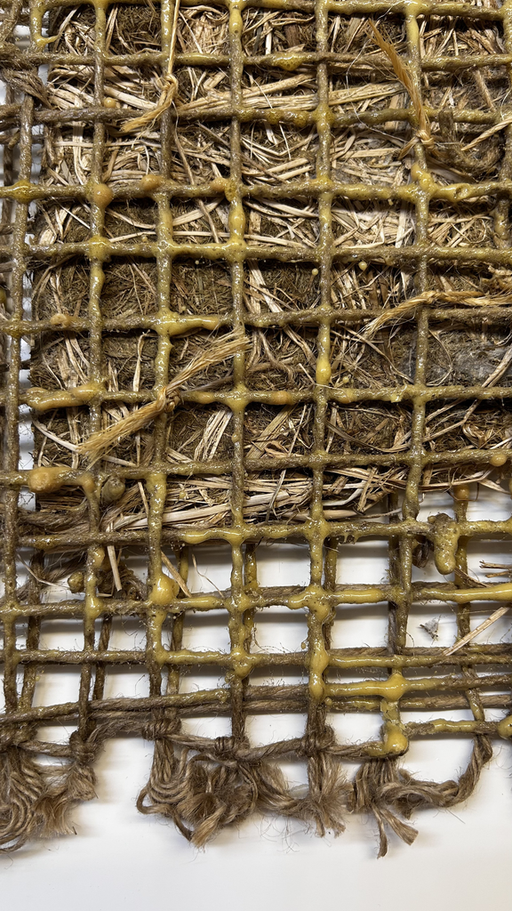

**Seleção de espécies**

Critérios para espécies de bioengenharia:

- **Pegamento por estaca** (capacidade de enraizar a partir de fragmentos vegetativos).
- **Sistema radicular profundo e ramificado**.
- **Tolerância** à saturação temporária (margens) ou à seca (vertentes).
- **Nativas locais**, evitando invasoras.
- **Cresc. rápido inicial** + persistência em longo prazo.

Exemplos brasileiros: *Erythrina* spp., *Salix* spp., *Gliricidia sepium*, *Sesbania* spp., *Vetiveria zizanioides* (reforço radicular extremo).

# 2 - APLICAÇÕES

## Estabilização de margens e taludes

### Margens fluviais

| Faixa | Técnica recomendada |
| --- | --- |
| Submersa | Enrocamento vegetado, biorrolos |
| Periodicamente úmida | Estacas vivas, feixes vivos |
| Borda super. | Plantio ciliár adensado |

### Taludes

- Re-perfilamento geométrico (declividade compatível com o solo).
- Construção de banquetas com canaletas verdes.
- Hidrossemeadura inicial + mantas + plantio enriquecedor.
- Em casos críticos: parede Krainer ou gabião vivo.

**Controle de voçorocas**

Sistema combinado:

1. **Desvio do escoamento** a montante (canaletas, dissipadores).
2. **Estabilização de cabeceiras** com retaludamento + cobertura.
3. **Paliçadas permeáveis** transversais espaçadas (gradativa retenção e deposição).
4. **Plantio adensado** com espécies pioneiras.
5. **Retentores de sedimento** a jusante (bacias de detenção, *check-dams*).
6. **Monitoramento** por pinos de erosão e fotorregistro georreferenciado.

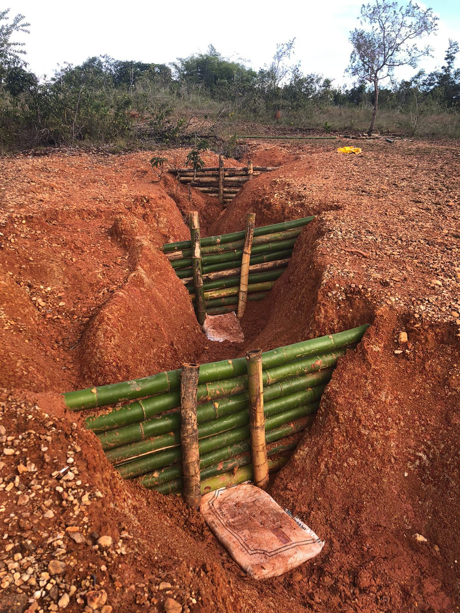

## Projeto integrado e monitoramento

### Etapas de projeto

1. **Diagnóstico**.
2. **Concepção** - seleção de técnicas por tipo de feição.
3. **Dimensionamento** - hidrológico, geotécnico, agronômico.
4. **Lista de mat./espécies** - nativas, quantitativos, calendário.
5. **Instalação** - início em transição seca-chuvosa.
6. **Monitoramento (2-3 anos)** - indicadores de pegamento, perda de solo, cobertura, sedimentação.

**Indicadores de sucesso**

| Indicador | Critério |
| --- | --- |
| Pegamento (90 d) | > 70% |
| Cobertura (1 ano) | > 80% |
| Perda de solo (pinos) | Decrescente entre eventos |
| Sedimentos retidos | Volume crescente |
| Estabilidade visual | Ausência de novas feições |

# Referências

## Bibliografia da aula

- GRAY, D. H.; SOTIR, R. B. **Biotechnical and soil bioengineering slope stabilization**. New York: Wiley, 1996.
- SCHIECHTL, H. M.; STERN, R. **Water bioengineering techniques for watercourse bank and shoreline protection**. Oxford: Blackwell, 1996.
- DURLO, M. A.; SUTILI, F. J. **Bioengenharia**: manejo biotécnico de cursos de água. 3. ed. Santa Maria: Edição do Autor, 2014. 192 p.